# Hypothesis Testing Part III

Albert Y. Kim

Wed Nov 18, 2016

```r
library(dplyr)
library(mosaic)
library(ggplot2)
library(readr)

# Set seed value
set.seed(76)

# Note you will need to change this line to whatever loads the data for you:
grades <- read_csv("../PS/grades.csv")
```

## LC1: Visuzalization

Both the following get the job done, but when using the boxplot:

- **Pro**: You can compare both groups with a single horizontal line
- **Con**: You lose information about the shape of the distribution

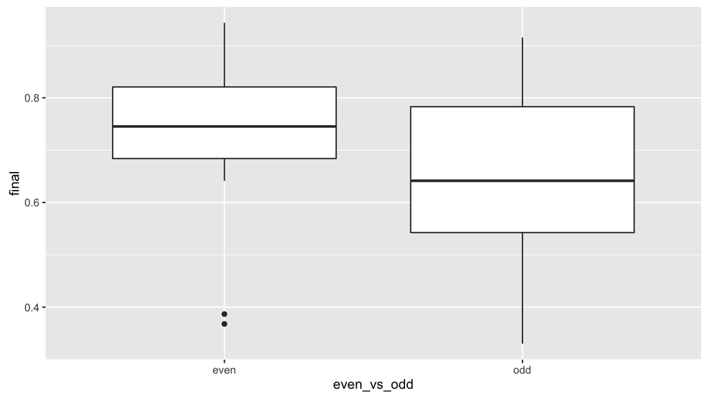

```r
ggplot(data=grades, aes(x=even_vs_odd, y=final)) +
  geom_boxplot()
```

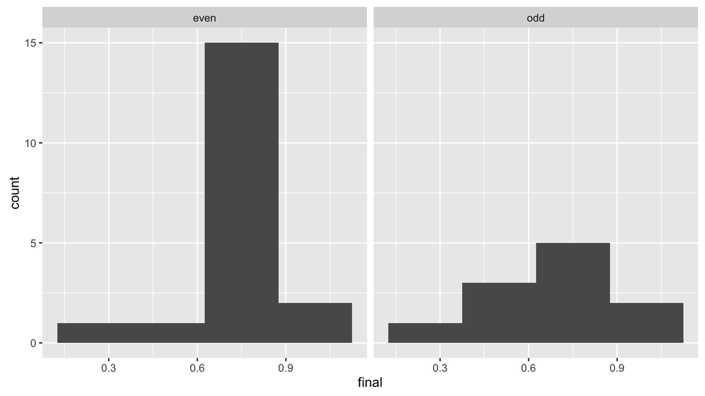

```r
ggplot(data=grades, aes(x=final)) +
  geom_histogram(binwidth = 0.25) +
  facet_wrap(~even_vs_odd)
```

No clear “slam-dunk” winner in my opinion! But really? # of letters in your last name?!?

## LC2: Setting the Seed Value

When demonstrating that the long code and the wrapper function code do the same thing **when randomization** is involved, we need to set the seed value to get **replicable random results**. 76 was an arbitrary choice of seed. Choose your favorite number.

## LC3: Perform Hypothesis Test

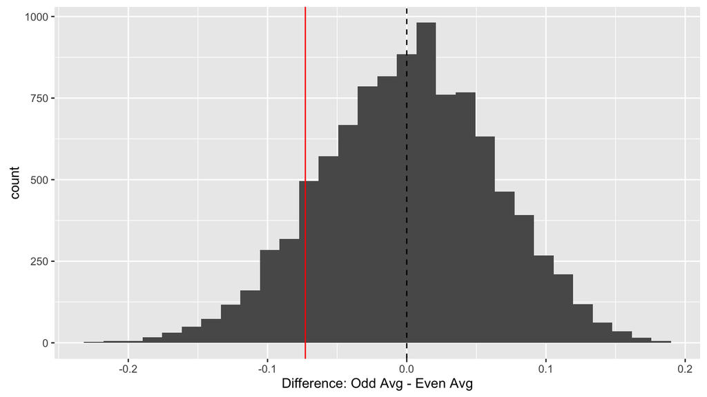

```r
# The true observed difference in averages i.e. the observed test statistic
observed_diff <- mean(final ~ even_vs_odd, data=grades) %>% diff()

# Simulate the null distribution of the test statistic:
simulations <- do(10000) * mean(final ~ shuffle(even_vs_odd), data=grades)
simulations <- simulations %>%
  as_data_frame() %>%
  mutate(difference=odd-even)

# Compare what we observed (red) to what happens if we assume no difference:
ggplot(data=simulations , aes(x=difference)) +
  geom_histogram() +
  geom_vline(xintercept = observed_diff, col="red") +
  geom_vline(xintercept = 0, linetype="dashed") +
  labs(x="Difference: Odd Avg - Even Avg")
```

Observing a difference in means of -0.073 still seems somewhat plausible. Also, not where it is centered: 0 i.e. no difference!

## p-Value

The p-value is the probability of observing a test statistic just as or more extreme than the one observed. In our case since $H_A: \mu_{odd} - \mu_{even} \neq 0$: i.e. there is a difference, we can have either

- A more extreme negative difference
- A more extreme positive difference

```r
simulations %>%
  mutate(more_extreme_left = difference <= observed_diff) %>%
  summarise(more_extreme_left = sum(more_extreme_left))
```

```
## # A tibble: 1 × 1
##   more_extreme_left
##               <int>
## 1              1248
```

There are 1248 values less than the observed difference of -0.073. So the p-value is

$$\frac{2 \times 1248 + 1}{10000 + 1} = 0.250$$
**Notes**:

1. Note we doubled the 1248 because we have a two-sided alternative $H_A: \mu_{odd} - \mu_{even} \neq 0$
2. We add 1 to both the numerator and denominator since we also need to account for the observed test statistic itself

## Other Alternatives

- Say we had $H_A: \mu_{odd} - \mu_{even} < 0$, more extreme would mean more negative, i.e. more to the left of the observed test statistic, i.e. the p-value would be
  $$\frac{1248 + 1}{10000 + 1} = 0.125$$
- Say we had $H_A: \mu_{odd} - \mu_{even} > 0$, more extreme would mean more positive, i.e. more to the right of the observed test statistic, i.e. the p-value would be
  $$\frac{(10000-1248) + 1}{10000 + 1} = 0.875$$

## Crucial Concept: Conclusion

We can only falsify the null hypothesis, never prove that it’s true.

- We are not
  - **Statistically**: Saying $H_0$ is true
  - **Conceptually**: We haven’t proven that odds and evens perform equally well.
- Rather, we are
  - **Statistically**: Failing to reject $H_0$: it might still be false, we just don’t have the evidence here.
  - **Conceptually**: Odds and evens might still perform differently, we just don’t have the evidence here to suggest so.

**Analogy**: Criminal justice system has two possible verdicts:

- **Guilty**
- **Not guilty**. This is NOT the same as saying the defendent is innocent, but rather they might still be guilty, but we can’t prove beyond a reasonable doubt that they are guilty.